# Programming Final Project

Michael Raminski (mraminski@gmail.com)

December 4, 2017

email address: mraminski@gmail.com

# Final Project - NFL Odds and Statistics

##### For this project, I wanted to look at various statistics relating to NFL football. Particularly, I wanted to see, over time, which teams have been the most and least successful; as well as how that compares to the sportbooks’ prediction for their season outcome (the “future” bet). In doing so, there were several interesting patterns that were discovered, including:

##### -The actual wins and point differentials show how dominant the New England Patriots have been, as well as how woeful several franchises, such as the Browns, Jaguars, and Raiders, have been.

##### -Under bets pay off slightly more than over bets. In researching this, it seems that psychologically, sports bettors prefer to bet Overs- they would rather bet for something to happen rather than something to not happen. As a result, it seems that the sportsbooks will adjust their numbers slightly higher to protect themselves from the potential exposure.

##### -The sportsbooks seem to have gotten dramatically more accurate with their futures predictions starting in the 2009 season. Their average Absolute Future Win Miss dropped more than 10 games, or approximately 12.5%. This could be the result of using more sophisticated data and analytical approaches in the new era of Big Data.

##### -The data shows some trend of the Percent of Over wins dropping as the Future Win prediction gets larger, which would be expected; however, the pattern is “spikey” and not incredibly strong. Although, there do seem to be potential “sweet spots” for Overs at 5.5, 6, and 11.5 games. As well as Unders at 5, 7, 8 and 10 wins.

#### Data Issues: My data was comprised of two sources:

##### -“Historical_Futures.csv” - giving the historical futures put out by the sportsbooks (source: http://www.sportsoddshistory.com/nfl-odds/). This required some manual work as the seasons were linked to different pages and unfortunately not provided in a single database.

##### -“Historical_Standings.csv” - giving the historical season results for each team (source: http://www.footballdb.com/standings/). This also required some manual work as the seasons were linked to different pages.

##### -There is actually a sparse amount of data that I was able to find, particularly on the historical odds, which I believe that the sportsbooks keep a pretty tight lid on.

#### Data Challenges: In tidying my data, there were a few issues that needed to be solved for:

##### -The data went back to 2000, but to capture the league as its currently constructed, I needed to start my data set beyond 2002 when the Houston Texans were founded. Because I wanted to include each teams previous year wins, I moved the starting season up to 2003. This way, there will also be the same number of teams each year, so that aggregate statistics can be compared fairly

##### -The Indianapolis Colts did not get a future win prediction for the 2011 season. After a little research, I found out that this was the year that their star quarterback, Peyton Manning, was injured going into the season. Because of the uncertainty of whether he would play or whether the Colts would be using a backup quarterback for the season, the sportsbooks weren’t able to post a win total. Because it is only one team in one year, I have left it in as a blank, removed NAs from some of my calculations, and called attention to it’s impact in some of the visualizations.

##### -The St Louis Rams relocated to Los Angeles just last year, so the data showed both “St Louis Rams” and “Los Angeles Rams”. In order to show the data at the franchise level, and to capture the current construction of the league, I replaced historical “St Louis Rams” records with “Los Angeles Rams”.

#### Definitions:

##### -“Futures” (“Predicted Wins”) - the sportsbooks’ preseason prediction for the total games each team will win in the coming season

##### -“Actual Wins” - the actual number of games a team won in a given season

##### -“Actual vs Predicted Wins” - The Actual Wins less the Predicted Wins

##### -“Settlement Week” - The week of the NFL season when the bet pays off (the correctness of the future prediction is officially validated)

##### -“Point Differential” - The difference in aggregate points scored by a team versus allowed to be scored against a team (a positive number means that, for the season, a team scored more points than they let up). This can perhaps be a better measure of success, rather than just season wins, which may be subject to more anomolies

##### -“Absolute Actual vs Predicted” (“Total Futures Win Miss”) - the absolute value of the Actual Wins less the Predicted Wins (regardless of direction over/under- how much did the sportsbook miss on their prediction). This will show overall how accurate the sportsbooks are at predicting season wins

##### -“Over” - when a team wins more games than was predicted

##### -“Under” - when a team wins fewer games than was predicted

##### -“Push” - when a team wins the exact same number of games as predicted

## Part 1 - Load in Data, Transform to Tidy Format, Join Datasets

### Read in First Data Set “Historical_Futures.csv” and name “futures”

#### Analyze structure of data set with dim() and glimpse()

#### Use fix_column_names function as dplyr verb to replace old variable names with snake case

```r
futures <- read_csv("Historical_Futures.csv")
futures %>% dim
```

```
[1] 543   8
```

```r
futures %>% glimpse
```

```
Observations: 543
Variables: 8
$ Year               <int> 2001, 2001, 2001, 2001, 2001, 2001, 2001, 2...
$ Team               <chr> "Arizona Cardinals", "Atlanta Falcons", "Ba...
$ `Win Total`        <dbl> 5.0, 5.5, 11.0, 8.0, 6.5, 7.0, 5.0, 4.5, 5....
$ `Over Odds`        <chr> "\xff\xff", "\xff\xff", "\xff\xff", "\xff\x...
$ `Under Odds`       <chr> "\xff\xff", "\xff\xff", "\xff\xff", "\xff\x...
$ `Week bet settled` <chr> "Week 15", "Week 11", "Week 16", "Week 11",...
$ `Actual Wins`      <int> 7, 7, 10, 3, 1, 13, 6, 7, 5, 8, 2, 12, 6, 6...
$ Result             <chr> "Over", "Over", "Under", "Under", "Under", ...
```

```r
fix_column_names <- function(x) {
  s <- gsub("\\.", "_", x) # Replace dots with underscores.
  s <- gsub("(.)([AZ][az]+)","\\1_\\2", s) # Separate w/ underscores on capitalization
  s <- tolower(gsub("([az09])([AZ])","\\1_\\2", s)) # lowercase
  s <- gsub("__","_", s) # double to single underscore
  s <- gsub("^[_,.]", "", s) # del first char underscore "_" or period "."
  s <- gsub(" ", "_", s) # remove spaces
}

names(futures) <- futures %>%
  colnames %>%
  fix_column_names
futures %>% head
```

```
# A tibble: 6 x 8
   year              team win_total  over_odds under_odds week_bet_settled
  <int>             <chr>     <dbl>      <chr>      <chr>            <chr>
1  2001 Arizona Cardinals       5.0 "\xff\xff" "\xff\xff"          Week 15
2  2001   Atlanta Falcons       5.5 "\xff\xff" "\xff\xff"          Week 11
3  2001  Baltimore Ravens      11.0 "\xff\xff" "\xff\xff"          Week 16
4  2001     Buffalo Bills       8.0 "\xff\xff" "\xff\xff"          Week 11
5  2001 Carolina Panthers       6.5 "\xff\xff" "\xff\xff"          Week 11
6  2001     Chicago Bears       7.0 "\xff\xff" "\xff\xff"          Week 11
# ... with 2 more variables: actual_wins <int>, result <chr>
```

### Transform “futures” into Tidy Format

#### Use dplyr with arrange(), filter(), mutate(), and select() commands to get data tidy

```r
futures <- futures %>%

  mutate(team = gsub("St Louis","Los Angeles", team)) %>%  #change historic "St Louis Rams" to "Los Angeles Rams"

  arrange(year, team) %>% #arrange by Year and Team Name (ascending, alphabetical)

  mutate(actual_vs_predicted = actual_wins - win_total, #show the difference in actual and predicted wins
         settlement_week = as.integer(gsub("Week ", "", week_bet_settled)), #get rid of "Week " and just show integer value for week
         odds_over = as.integer(over_odds), #convert from character to integer
         odds_under = as.integer(under_odds), #convert from character to integer
         predicted_wins = win_total, #rename column
         last_year_wins_f = lag(actual_wins, 32)) %>%

  select(year, team, predicted_wins, odds_over, odds_under, actual_wins, actual_vs_predicted, result, settlement_week, last_year_wins_f) %>%
  filter(year >= "2003" & year < "2017" & is.na(predicted_wins) == FALSE) #Only use data beyond 2003 (but not current 2017 year which isn't complete), this is where odds are provided, all current franchises are in league, and current conferences are in place

futures %>% head
```

```
# A tibble: 6 x 10
   year              team predicted_wins odds_over odds_under actual_wins
  <int>             <chr>          <dbl>     <int>      <int>       <int>
1  2003 Arizona Cardinals            5.0       125       -155           4
2  2003   Atlanta Falcons            9.5      -115       -115           5
3  2003  Baltimore Ravens            7.5      -160        130          10
4  2003     Buffalo Bills            8.5      -130        100           6
5  2003 Carolina Panthers            7.5      -115       -115          11
6  2003     Chicago Bears            7.5       130       -160           7
# ... with 4 more variables: actual_vs_predicted <dbl>, result <chr>,
#   settlement_week <int>, last_year_wins_f <int>
```

### Read in Second Data Set “Historical_Standings.csv” and name “standings”

#### Analyze structure of data set with dim() and glimpse()

#### Use fix_column_names function as dplyr verb to replace old variable names with snake case

```r
standings <- read_csv("Historical_Standings.csv")
standings %>% dim
```

```
[1] 542  13
```

```r
standings %>% glimpse
```

```
Observations: 542
Variables: 13
$ Year <int> 2000, 2000, 2000, 2000, 2000, 2000, 2000, 2000, 2000, 200...
$ Team <chr> "y - Miami Dolphins", "x - Indianapolis Colts", "New York...
$ W    <int> 11, 10, 9, 8, 5, 13, 12, 9, 7, 4, 3, 12, 11, 7, 6, 1, 12,...
$ L    <int> 5, 6, 7, 8, 11, 3, 4, 7, 9, 12, 13, 4, 5, 9, 10, 15, 4, 5...
$ T    <int> 0, 0, 0, 0, 0, 0, 0, 0, 0, 0, 0, 0, 0, 0, 0, 0, 0, 0, 0, ...
$ Pct  <dbl> 0.688, 0.625, 0.562, 0.500, 0.312, 0.812, 0.750, 0.562, 0...
$ PF   <int> 323, 429, 321, 315, 276, 346, 333, 321, 367, 185, 161, 47...
$ PA   <int> 226, 326, 321, 350, 338, 191, 165, 255, 327, 359, 419, 29...
$ Home <chr> "5/3/2000", "6/2/2000", "5/3/2000", "5/3/2000", "3/5/2000...
$ Away <chr> "6/2/2000", "4/4/2000", "4/4/2000", "3/5/2000", "2/6/2000...
$ Div  <chr> "5/3/2000", "5/3/2000", "6/2/2000", "2/6/2000", "2/6/2000...
$ Conf <chr> "9/3/2000", "8/4/2000", "6/6/2000", "6/6/2000", "5/7/2000...
$ NFC  <chr> "2/2/2000", "2/2/2000", "3/1/2000", "2/2/2000", "0-4-0", ...
```

```r
fix_column_names <- function(x) {
  s <- gsub("\\.", "_", x) # Replace dots with underscores.
  s <- gsub("(.)([AZ][az]+)","\\1_\\2", s) # Separate w/ underscores on capitalization
  s <- tolower(gsub("([az09])([AZ])","\\1_\\2", s)) # lowercase
  s <- gsub("__","_", s) # double to single underscore
  s <- gsub("^[_,.]", "", s) # del first char underscore "_" or period "."
  s <- gsub(" ", "_", s) # remove spaces
}

names(standings) <- standings %>%
  colnames %>%
  fix_column_names
standings %>% head
```

```
# A tibble: 6 x 13
   year                   team     w     l     t   pct    pf    pa
  <int>                  <chr> <int> <int> <int> <dbl> <int> <int>
1  2000     y - Miami Dolphins    11     5     0 0.688   323   226
2  2000 x - Indianapolis Colts    10     6     0 0.625   429   326
3  2000          New York Jets     9     7     0 0.562   321   321
4  2000          Buffalo Bills     8     8     0 0.500   315   350
5  2000   New England Patriots     5    11     0 0.312   276   338
6  2000   z - Tennessee Titans    13     3     0 0.812   346   191
# ... with 5 more variables: home <chr>, away <chr>, div <chr>,
#   conf <chr>, nfc <chr>
```

### Transform “standings” into Tidy Format

#### Use dplyr with arrange(), filter(), mutate(), and select() commands to get data tidy

```r
standings <- standings %>%

  mutate(team = gsub("St. Louis","Los Angeles",gsub(" - ","",gsub("^[x - ,y - ,z - ]", "", team)))) %>%

  arrange(year, team) %>% #arrange by Year and Team Name (ascending, alphabetical)

  mutate(wins = w, #make name more intuitive
         points_for = pf, #make name more intuitive
         points_against = pa, #make name more intuitive
         point_differential = pf - pa, #calculate point differential
         last_year_wins_s = lag(wins, 32), #calculate last year wins
         last_year_point_differential = lag(point_differential, 32)) %>% #calculate last year point differential

  filter(year >= "2003") %>% #Only use data beyond 2003 to match futures

  select(-(w:nfc))
standings %>% head
```

```
# A tibble: 6 x 8
   year              team  wins points_for points_against
  <int>             <chr> <int>      <int>          <int>
1  2003 Arizona Cardinals     4        225            452
2  2003   Atlanta Falcons     5        299            422
3  2003  Baltimore Ravens    10        391            281
4  2003     Buffalo Bills     6        243            279
5  2003 Carolina Panthers    11        325            304
6  2003     Chicago Bears     7        283            346
# ... with 3 more variables: point_differential <int>,
#   last_year_wins_s <int>, last_year_point_differential <int>
```

### Join Data Sets “futures” and “standings” and name “joined_data”

#### Use dplyr full_join() command, check dimensions to make sure the number of rows matches individual data sets

#### Use dplyr mutate() command to create a variable “win_check” that calculates the difference in the wins reported by each data set

#### Use dplyr summarise() command to get the sum of the “win_check” variable, and confirm they are both 0

```r
joined_data <- full_join(futures, standings)
joined_data %>% dim
```

```
[1] 448  16
```

```r
joined_data %>% head
```

```
# A tibble: 6 x 16
   year              team predicted_wins odds_over odds_under actual_wins
  <int>             <chr>          <dbl>     <int>      <int>       <int>
1  2003 Arizona Cardinals            5.0       125       -155           4
2  2003   Atlanta Falcons            9.5      -115       -115           5
3  2003  Baltimore Ravens            7.5      -160        130          10
4  2003     Buffalo Bills            8.5      -130        100           6
5  2003 Carolina Panthers            7.5      -115       -115          11
6  2003     Chicago Bears            7.5       130       -160           7
# ... with 10 more variables: actual_vs_predicted <dbl>, result <chr>,
#   settlement_week <int>, last_year_wins_f <int>, wins <int>,
#   points_for <int>, points_against <int>, point_differential <int>,
#   last_year_wins_s <int>, last_year_point_differential <int>
```

```r
joined_data <- joined_data %>%
  mutate(win_check = actual_wins - wins,
         last_year_win_check = last_year_wins_f - last_year_wins_s)

win_check <- joined_data %>%
  summarise(total_win_diff = sum(win_check, na.rm = TRUE),
            total_Last_year_win_diff = sum(last_year_win_check, na.rm = TRUE))
win_check
```

```
# A tibble: 1 x 2
  total_win_diff total_Last_year_win_diff
           <int>                    <int>
1              0                        0
```

### Transform “joined_data” into Tidy Format

#### Use dplyr arrange(), mutate(), and select() commands to get data tidy

```r
joined_data <- joined_data %>%
  arrange(year, team) %>% #arrange by Year and Team Name (ascending, alphabetical)

  mutate(absolute_actual_vs_predicted = abs(actual_vs_predicted)) %>%

  select(-wins,-win_check,-last_year_win_check)
joined_data %>% head
```

```
# A tibble: 6 x 16
   year              team predicted_wins odds_over odds_under actual_wins
  <int>             <chr>          <dbl>     <int>      <int>       <int>
1  2003 Arizona Cardinals            5.0       125       -155           4
2  2003   Atlanta Falcons            9.5      -115       -115           5
3  2003  Baltimore Ravens            7.5      -160        130          10
4  2003     Buffalo Bills            8.5      -130        100           6
5  2003 Carolina Panthers            7.5      -115       -115          11
6  2003     Chicago Bears            7.5       130       -160           7
# ... with 10 more variables: actual_vs_predicted <dbl>, result <chr>,
#   settlement_week <int>, last_year_wins_f <int>, points_for <int>,
#   points_against <int>, point_differential <int>,
#   last_year_wins_s <int>, last_year_point_differential <int>,
#   absolute_actual_vs_predicted <dbl>
```

## Part 2 - Exploratory Data Analysis

### Use “joined_data” set to look at the distribution of key metrics using ggplot()

#### Predicted Wins

##### The boxplot shows the difference in the distribution of futures by each year. Years such as 2008 and 2013 have very narrow interquartile ranges, while 2011 has a large interquartile range. Additionally, a majority of the medians are above the 8 win mark, which may suggest that futures skew to the high side.

##### The histogram shows, as we would expect, that the distribution of the futures are approximately normal around 8 wins

##### Both the boxplot and histogram show that the range of futures is never less than 4.5 or greater than 12.

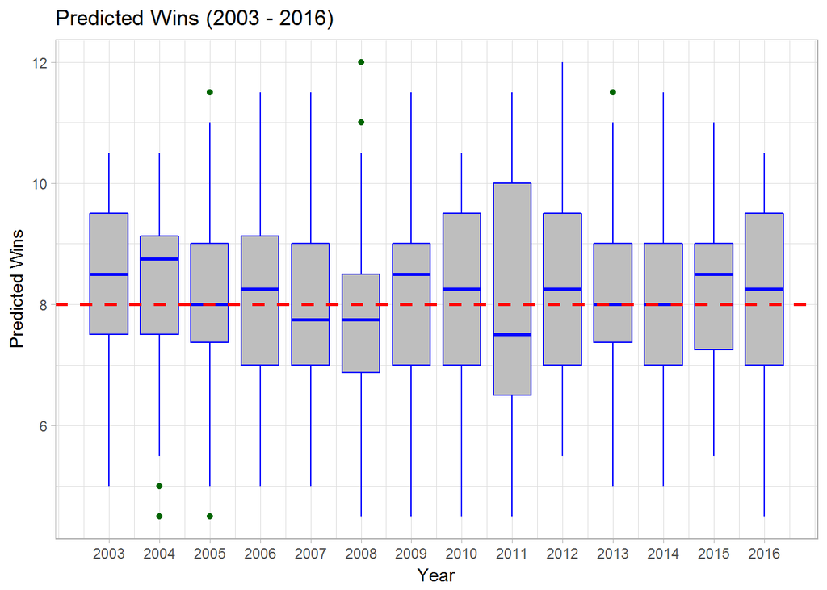

```r
joined_data %>%
  ggplot(aes(year, predicted_wins)) +
  geom_boxplot(aes(group = year), color = "blue", fill = "gray", outlier.color = "dark green") +
  geom_hline(aes(yintercept = median(predicted_wins, na.rm = TRUE)), color = "red", linetype=2, size = 1, show.legend = FALSE) +
  scale_x_continuous(breaks = c(2003:2016)) +
  theme_light() +
  labs(title="Predicted Wins (2003 - 2016)", x="Year", y="Predicted Wins")
```

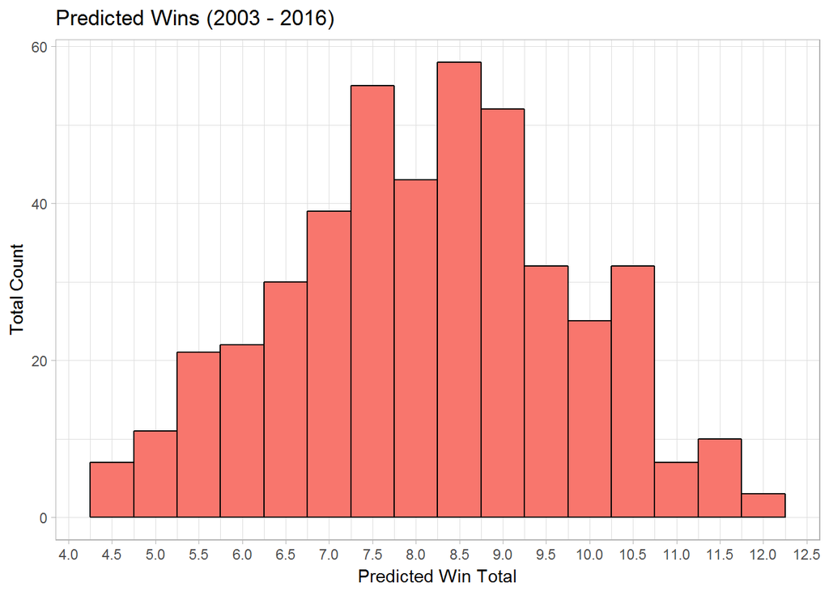

```r
joined_data %>%
  ggplot() +
  geom_histogram(aes(predicted_wins, fill = "orange"), color = "black", binwidth = .5, show.legend = FALSE) +
  scale_x_continuous(breaks = seq(0,16,.5)) +
  theme_light() +
  labs(title="Predicted Wins (2003 - 2016)", x="Predicted Win Total", y="Total Count")
```

#### Actual Wins

##### The boxplot shows that the low wins for a given year ranges between 0 and 4, while the high wins ranges from 12 to 16.

##### The histogram shows, as we would expect, that the distribution of the actual wins are approximately normal around 8 wins

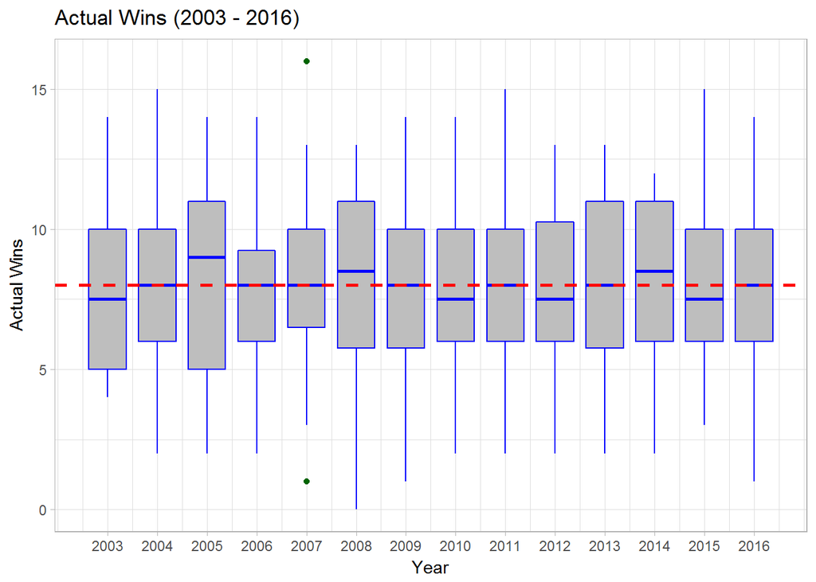

```r
joined_data %>%
  ggplot(aes(year, actual_wins)) +
  geom_boxplot(aes(group = year), color = "blue", fill = "gray", outlier.color = "dark green") +
  geom_hline(aes(yintercept = median(actual_wins, na.rm = TRUE)), color = "red", linetype=2, size = 1, show.legend = FALSE) +
  scale_x_continuous(breaks = c(2003:2016)) +
  theme_light() +
  labs(title="Actual Wins (2003 - 2016)", x="Year", y="Actual Wins")
```

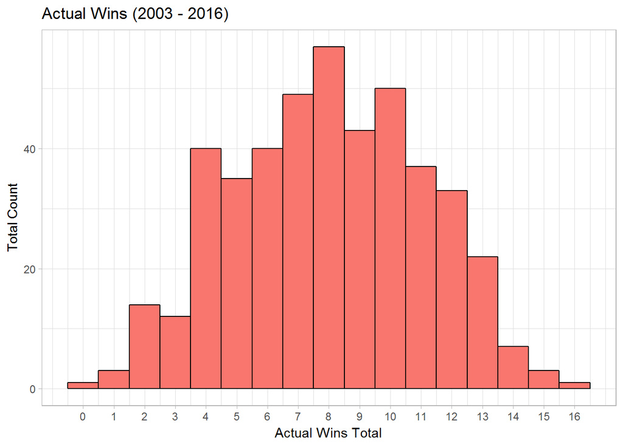

```r
joined_data %>%
  ggplot() +
  geom_histogram(aes(actual_wins, fill = "orange"), color = "black", binwidth = 1, show.legend = FALSE) +
  scale_x_continuous(breaks = seq(0,16,1)) +
  theme_light() +
  labs(title="Actual Wins (2003 - 2016)", x="Actual Wins Total", y="Total Count")
```

#### Actual vs Predicted Wins

##### Both the boxplot and the histogram show the data fairly well centered around 0.

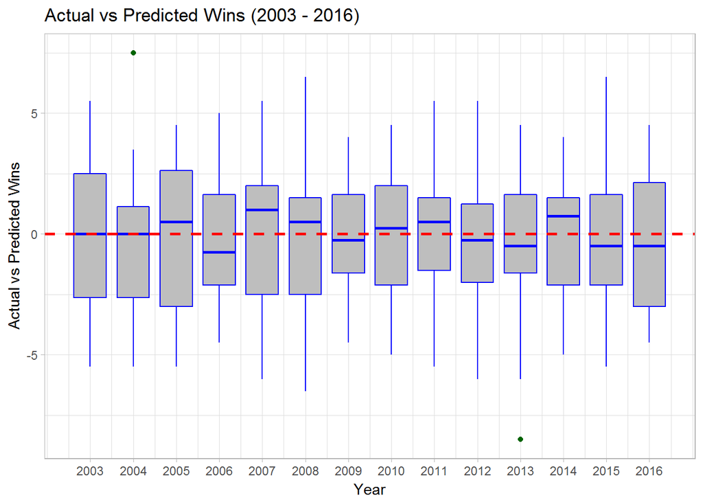

```r
joined_data %>%
  ggplot(aes(year, actual_vs_predicted)) +
  geom_boxplot(aes(group = year), color = "blue", fill = "gray", outlier.color = "dark green") +
  geom_hline(aes(yintercept = median(actual_vs_predicted, na.rm = TRUE)), color = "red", linetype=2, size = 1, show.legend = FALSE) +
  scale_x_continuous(breaks = c(2003:2016)) +
  theme_light() +
  labs(title="Actual vs Predicted Wins (2003 - 2016)", x="Year", y="Actual vs Predicted Wins")
```

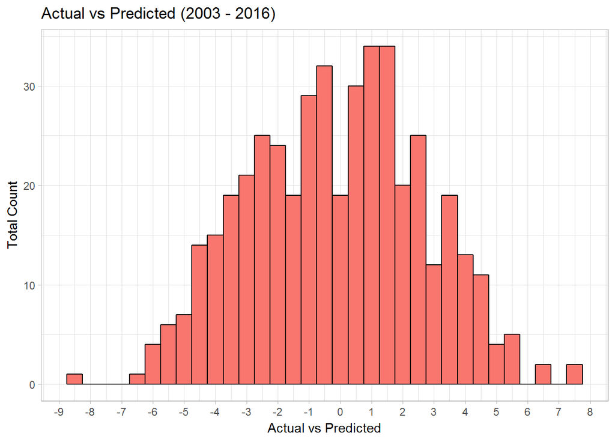

```r
joined_data %>%
  ggplot() +
  geom_histogram(aes(actual_vs_predicted, fill = "orange"), color = "black", binwidth = .5, show.legend = FALSE) +
  scale_x_continuous(breaks = seq(-10,10)) +
  theme_light() +
  labs(title="Actual vs Predicted (2003 - 2016)", x="Actual vs Predicted", y="Total Count")
```

#### Settlement Week

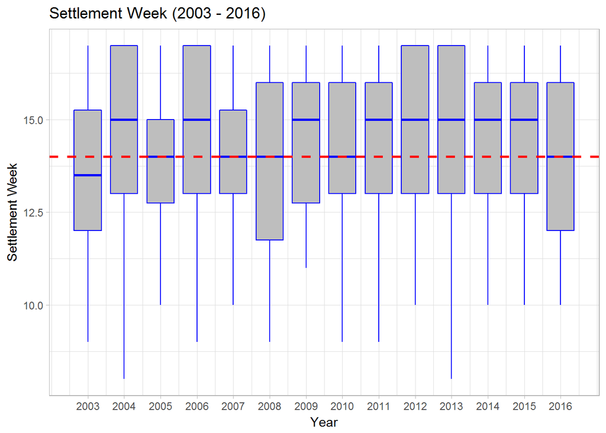

```r
joined_data %>%
  ggplot(aes(year, settlement_week)) +
  geom_boxplot(aes(group = year), color = "blue", fill = "gray", outlier.color = "dark green") +
  geom_hline(aes(yintercept = median(settlement_week, na.rm = TRUE)), color = "red", linetype=2, size = 1, show.legend = FALSE) +
  scale_x_continuous(breaks = c(2003:2016)) +
  theme_light() +
  labs(title="Settlement Week (2003 - 2016)", x="Year", y="Settlement Week")
```

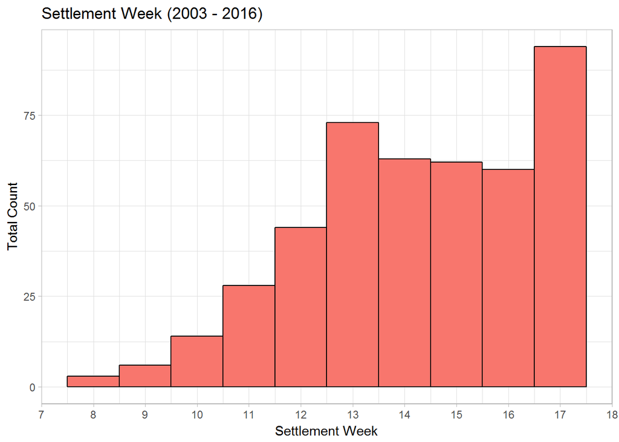

```r
joined_data %>%
  ggplot() +
  geom_histogram(aes(settlement_week, fill = "orange"), color = "black", binwidth = 1, show.legend = FALSE) +
  scale_x_continuous(breaks = seq(1,18)) +
  theme_light() +
  labs(title="Settlement Week (2003 - 2016)", x="Settlement Week", y="Total Count")
```

#### Point Differential

##### The boxplot shows an interesting picture. The New England Patriots undefeated season certainly sticks out as the top end of the 2007 upper whisker (as it does in the very far right of the histogram). There are also more outliers in 2016 than we’ve seen in any boxplots for other metrics.

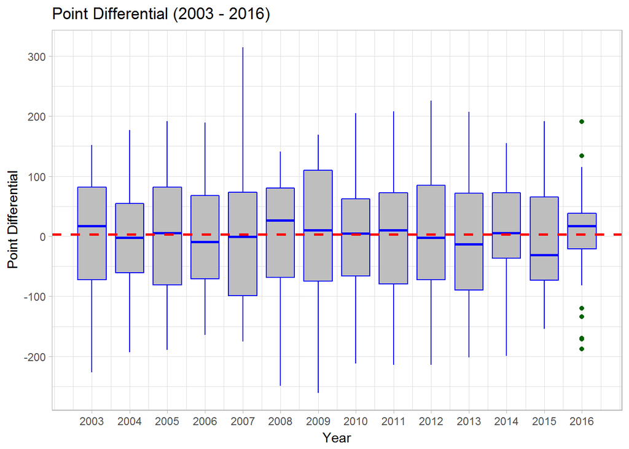

```r
joined_data %>%
  ggplot(aes(year, point_differential)) +
  geom_boxplot(aes(group = year), color = "blue", fill = "gray", outlier.color = "dark green") +
  geom_hline(aes(yintercept = median(point_differential, na.rm = TRUE)), color = "red", linetype=2, size = 1, show.legend = FALSE) +
  scale_x_continuous(breaks = c(2003:2016)) +
  theme_light() +
  labs(title="Point Differential (2003 - 2016)", x="Year", y="Point Differential")
```

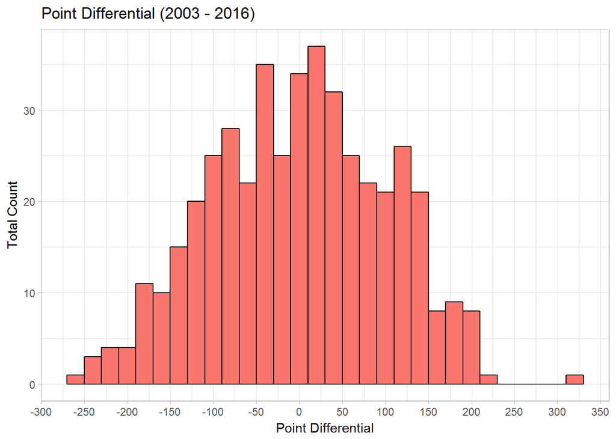

```r
joined_data %>%
  ggplot() +
  geom_histogram(aes(point_differential, fill = "orange"), color = "black", binwidth = 20, show.legend = FALSE) +
  scale_x_continuous(breaks = seq(-500,500,50)) +
  theme_light() +
  labs(title="Point Differential (2003 - 2016)", x="Point Differential", y="Total Count")
```

#### Absolute Actual vs Predicted

##### The histogram interestingly shows a fairly strong lognormal pattern.

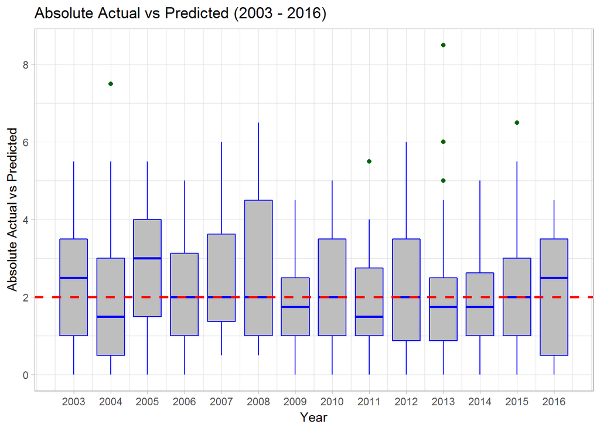

```r
joined_data %>%
  ggplot(aes(year, absolute_actual_vs_predicted)) +
  geom_boxplot(aes(group = year), color = "blue", fill = "gray", outlier.color = "dark green") +
  geom_hline(aes(yintercept = median(absolute_actual_vs_predicted, na.rm = TRUE)), color = "red", linetype=2, size = 1, show.legend = FALSE) +
  scale_x_continuous(breaks = c(2003:2016)) +
  theme_light() +
  labs(title="Absolute Actual vs Predicted (2003 - 2016)", x="Year", y="Absolute Actual vs Predicted")
```

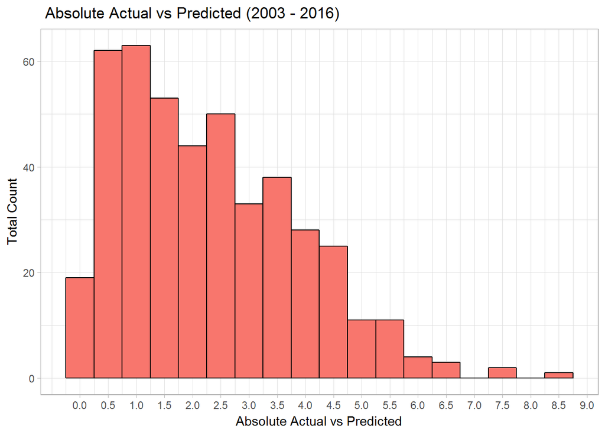

```r
joined_data %>%
  ggplot() +
  geom_histogram(aes(absolute_actual_vs_predicted, fill = "orange"), color = "black", binwidth = .5, show.legend = FALSE) +
  scale_x_continuous(breaks = seq(0,16,.5)) +
  theme_light() +
  labs(title=" Absolute Actual vs Predicted (2003 - 2016)", x="Absolute Actual vs Predicted", y="Total Count")
```

### Use “joined_data” set to create a summary by year named “by_year”

#### Use dplyr group_by(), mutate() and summarise()

```r
by_year <- joined_data %>%
  group_by(year) %>%

  mutate(count_over = sum(result == "Over", na.rm = TRUE),
         count_under = sum(result == "Under", na.rm = TRUE),
         count_push = sum(result == "Push", na.rm = TRUE)) %>%

  summarise(total_predicted_wins = sum(predicted_wins, na.rm = TRUE),
            total_scored = sum(points_for, na.rm = TRUE),
            total_futures_win_miss = sum(absolute_actual_vs_predicted, na.rm = TRUE),
            count_over = mean(count_over, na.rm = TRUE),
            count_under = mean(count_under, na.rm = TRUE),
            count_push = mean(count_push, na.rm = TRUE))
by_year %>% head
```

```
# A tibble: 6 x 7
   year total_predicted_wins total_scored total_futures_win_miss
  <int>                <dbl>        <int>                  <dbl>
1  2003                265.5        10666                   79.5
2  2004                261.5        11000                   69.5
3  2005                260.0        10556                   91.0
4  2006                263.0        10577                   71.0
5  2007                257.5        11104                   81.5
6  2008                252.0        11279                   84.0
# ... with 3 more variables: count_over <dbl>, count_under <dbl>,
#   count_push <dbl>
```

#### Total Points scored by Year

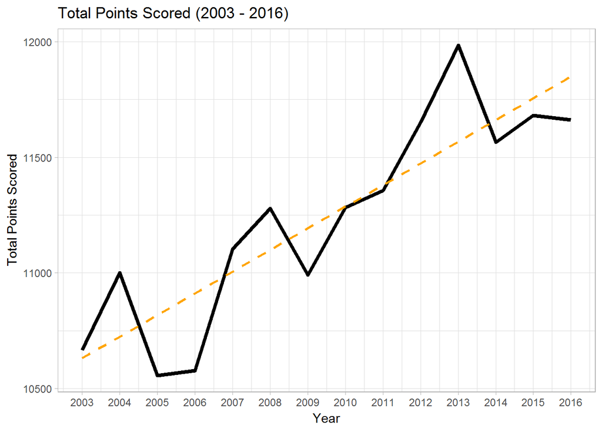

```r
by_year %>%
  ggplot(aes(year, total_scored)) +
  geom_line(color = "black", size = 1.5) +
  geom_smooth(method = "lm", color="orange", linetype=2, se = FALSE) +
  scale_x_continuous(breaks = c(2003:2016)) +
  theme_light() +
  labs(title="Total Points Scored (2003 - 2016)", x="Year", y="Total Points Scored")
```

#### Total Predicted Wins by Year

##### This chart is interesting, it shows that in most years the aggregate of futures is higher than the total number of games. This is especially the case considering 2011 is understated by not having included the Indianapolis Colts. This suggests that the sportsbooks are skewing their futures toward the high side. This is likely because more bets are expected to come in on the Over. This suggests some opportunity for betting Unders. The tables suggest that Under hits the most, but not by a incredibly large margin.

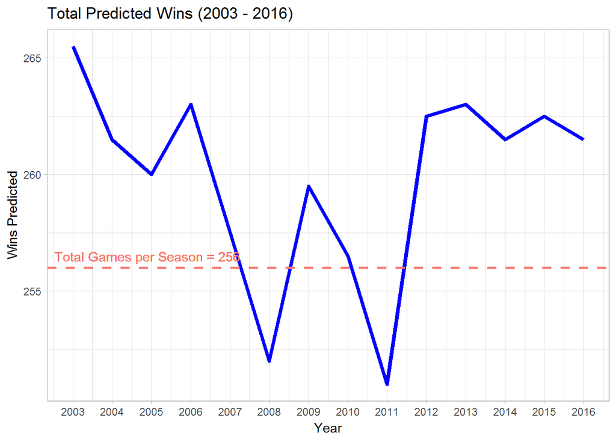

```r
by_year %>%
  ggplot(aes(year, total_predicted_wins)) +
  geom_line(color = "blue", size = 1.5) +
  geom_hline(aes(yintercept = 256, color = "red"), linetype=2, size = 1, show.legend = FALSE) +
  geom_text(aes(2003, 256.5, label = "Total Games per Season = 256", color = "red", hjust = 0.1), show.legend = FALSE) +
  scale_x_continuous(breaks = c(2003:2016)) +
  theme_light() +
  labs(title="Total Predicted Wins (2003 - 2016)", x="Year", y="Wins Predicted")
```

```r
over_vs_under <- by_year %>%
  summarise(total_over = sum(count_over),
            total_under = sum(count_under),
            total_push = sum(count_push))
over_vs_under
```

```
# A tibble: 1 x 3
  total_over total_under total_push
       <dbl>       <dbl>      <dbl>
1        211         217         19
```

```r
over_vs_under_perc <- by_year %>%
  summarise(total_over_perc = sum(count_over) / (sum(count_over) + sum(count_under) + sum(count_push)),
            total_under_perc = sum(count_under) / (sum(count_over) + sum(count_under) + sum(count_push)),
            total_push_perc = sum(count_push) / (sum(count_over) + sum(count_under) + sum(count_push)))
over_vs_under_perc
```

```
# A tibble: 1 x 3
  total_over_perc total_under_perc total_push_perc
            <dbl>            <dbl>           <dbl>
1       0.4720358        0.4854586      0.04250559
```

#### Total Futures Wins Missed

##### This chart shows the total of how much the sportsbooks are missing the total wins each year. They have shown a drastic improvement starting between the 2008 and 2009 seasons, perhaps the result of more sophisticated data and analytics.

```r
all_year_avg <- by_year %>%
  summarise(average = mean(total_futures_win_miss))
all_year_avg %>% head
```

```
# A tibble: 1 x 1
  average
    <dbl>
1   73.25
```

```r
early_avg <- by_year %>%
  filter(year < "2009") %>%
  summarise(average = mean(total_futures_win_miss))
early_avg %>% head
```

```
# A tibble: 1 x 1
   average
     <dbl>
1 79.41667
```

```r
late_avg <- by_year %>%
  filter(year >= "2009") %>%
  summarise(average = mean(total_futures_win_miss))
late_avg %>% head
```

```
# A tibble: 1 x 1
  average
    <dbl>
1  68.625
```

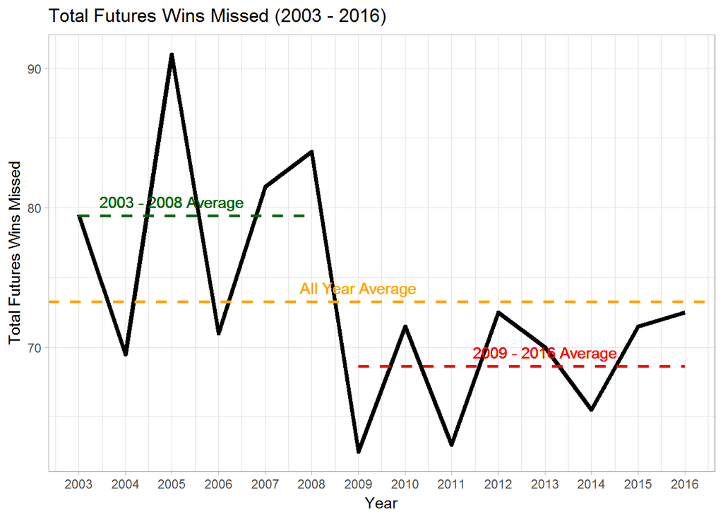

```r
by_year %>%
  ggplot(aes(year, total_futures_win_miss)) +
  geom_line(color = "black", size = 1.5) +
  geom_segment(aes(x = 2003, y = early_avg, xend = 2008, yend = early_avg), color = "dark green", linetype=2, size = 1) +
  geom_text(aes(2005, early_avg + 1, label = "2003 - 2008 Average"), color = "dark green") +
  geom_hline(aes(yintercept = all_year_avg), color = "orange", linetype=2, size = 1) +
  geom_text(aes(2009, all_year_avg + 1, label = "All Year Average"), color = "orange") +
  geom_segment(aes(x = 2009, y = late_avg, xend = 2016, yend = late_avg), color = "red", linetype=2, size = 1) +
  geom_text(aes(2013, late_avg + 1, label = "2009 - 2016 Average"), color = "red") +
  scale_x_continuous(breaks = c(2003:2016)) +
  theme_light() +
  labs(title="Total Futures Wins Missed (2003 - 2016)", x="Year", y="Total Futures Wins Missed")
```

#### Use dplyr group_by(), mutate() and summarise()

```r
by_future <- joined_data %>%
  group_by(predicted_wins) %>%

  mutate(count_over = sum(result == "Over", na.rm = TRUE),
         count_under = sum(result == "Under", na.rm = TRUE),
         count_push = sum(result == "Push", na.rm = TRUE)) %>%

  summarise(count = n(),
            avg_actual_vs_predicted = mean(actual_vs_predicted, na.rm = TRUE),
            avg_futures_win_miss = mean(absolute_actual_vs_predicted, na.rm = TRUE),
            pct_over = mean(count_over) / (mean(count_over) + mean(count_under) + mean(count_push)),
            pct_under = mean(count_under) / (mean(count_over) + mean(count_under) + mean(count_push)),
            pct_push = mean(count_push) / (mean(count_over) + mean(count_under) + mean(count_push)))
by_future %>% head
```

```
# A tibble: 6 x 7
  predicted_wins count avg_actual_vs_predicted avg_futures_win_miss
           <dbl> <int>                   <dbl>                <dbl>
1            4.5     7               1.6428571             3.500000
2            5.0    11              -0.6363636             1.363636
3            5.5    21               0.6904762             2.642857
4            6.0    22               1.1818182             1.727273
5            6.5    30              -0.3000000             2.266667
6            7.0    39              -0.4615385             2.358974
# ... with 3 more variables: pct_over <dbl>, pct_under <dbl>,
#   pct_push <dbl>
```

#### Average Actual vs Predicted Wins

##### The trend suggests that the higher the future, the less likely it is to go Over

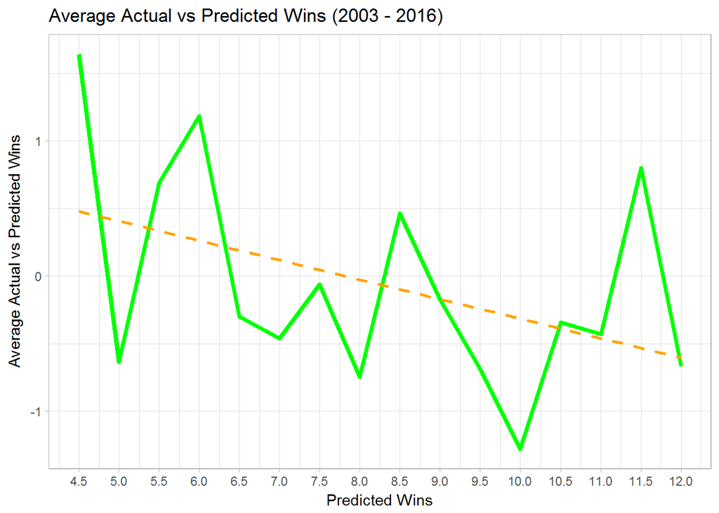

```r
by_future %>%
  ggplot(aes(predicted_wins, avg_actual_vs_predicted)) +
  geom_line(color = "green", size = 1.5) +
  geom_smooth(method = "lm", color="orange", linetype=2, se = FALSE) +
  scale_x_continuous(breaks = seq(0,16,.5)) +
  theme_light() +
  labs(title="Average Actual vs Predicted Wins (2003 - 2016)", x="Predicted Wins", y="Average Actual vs Predicted Wins")
```

#### Average Futures Win Miss

##### This trend suggests the the sportsbooks are predicting the higher future totals more accurately.

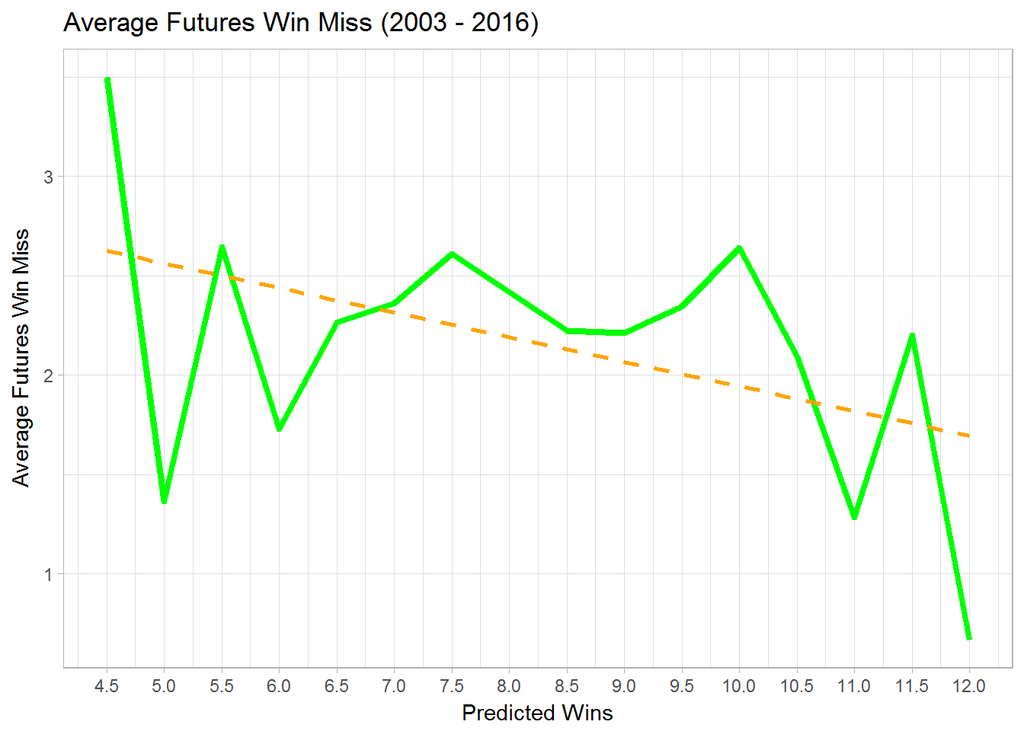

```r
by_future %>%
  ggplot(aes(predicted_wins, avg_futures_win_miss)) +
  geom_line(color = "green", size = 1.5) +
  geom_smooth(method = "lm", color="orange", linetype=2, se = FALSE) +
  scale_x_continuous(breaks = seq(0,16,.5)) +
  theme_light() +
  labs(title="Average Futures Win Miss (2003 - 2016)", x="Predicted Wins", y="Average Futures Win Miss")
```

#### Percent Over

##### There isn’t too strong of a pattern in the percent of going Over by each future prediction.

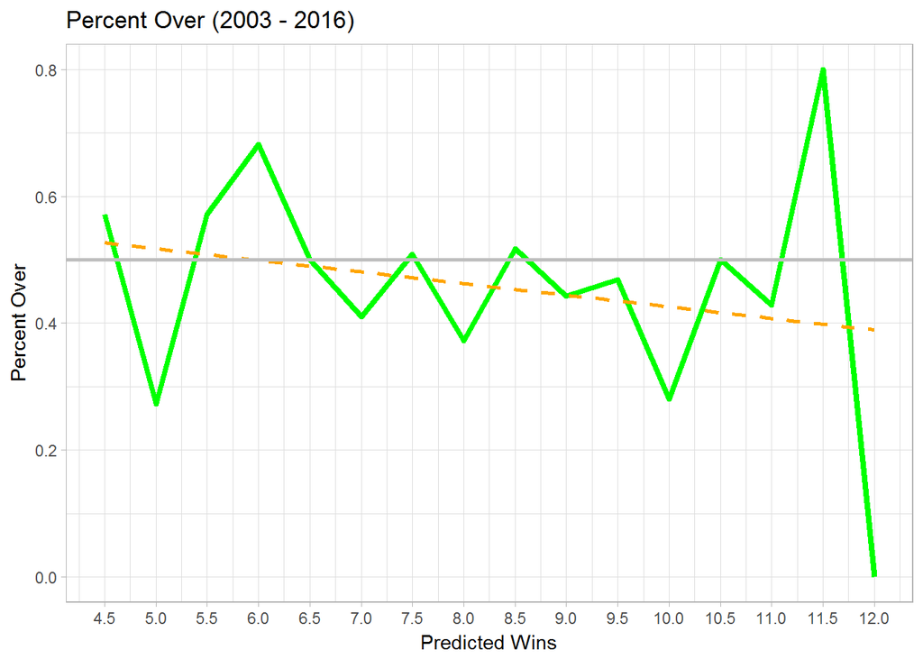

```r
by_future %>%
  ggplot(aes(predicted_wins, pct_over)) +
  geom_line(color = "green", size = 1.5) +
  geom_smooth(method = "lm", color="orange", linetype=2, se = FALSE) +
  scale_x_continuous(breaks = seq(0,16,.5)) +
  geom_hline(aes(yintercept = .5), color = "gray", linetype=1, size = 1) +
  theme_light() +
  labs(title="Percent Over (2003 - 2016)", x="Predicted Wins", y="Percent Over")
```

#### Percent Under

##### This is a reverse of the previous chart.

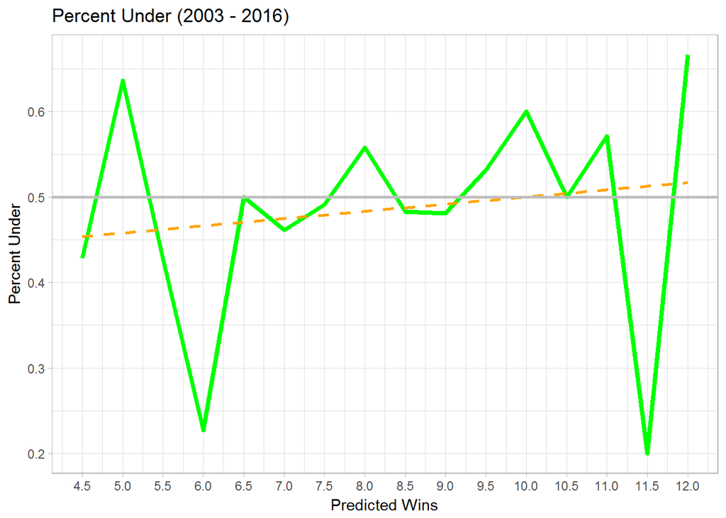

```r
by_future %>%
  ggplot(aes(predicted_wins, pct_under)) +
  geom_line(color = "green", size = 1.5) +
  geom_smooth(method = "lm", color="orange", linetype=2, se = FALSE) +
  scale_x_continuous(breaks = seq(0,16,.5)) +
  geom_hline(aes(yintercept = .5), color = "gray", linetype=1, size = 1) +
  theme_light() +
  labs(title="Percent Under (2003 - 2016)", x="Predicted Wins", y="Percent Under")
```

#### Use dplyr group_by() and summarise()

```r
by_team <- joined_data %>%
  group_by(team) %>%
  summarise(total_predicted_wins = sum(predicted_wins, na.rm = TRUE),
            total_actual_wins = sum(actual_wins, na.rm = TRUE),
            total_actual_vs_predicted = sum(actual_vs_predicted, na.rm = TRUE),
            total_futures_win_miss = sum(absolute_actual_vs_predicted, na.rm = TRUE),
            total_scored = sum(points_for, na.rm = TRUE),
            total_against = sum(points_against, na.rm = TRUE),
            total_point_differential = sum(point_differential, na.rm = TRUE))
by_team %>% head
```

```
# A tibble: 6 x 8
               team total_predicted_wins total_actual_wins
              <chr>                <dbl>             <int>
1 Arizona Cardinals                101.5               106
2   Atlanta Falcons                119.0               120
3  Baltimore Ravens                123.0               128
4     Buffalo Bills                100.0                93
5 Carolina Panthers                113.5               119
6     Chicago Bears                113.5               110
# ... with 5 more variables: total_actual_vs_predicted <dbl>,
#   total_futures_win_miss <dbl>, total_scored <int>, total_against <int>,
#   total_point_differential <int>
```

#### Total Predicted Wins

##### This shows the teams that have been the heaviest favorites and the biggest dogs.

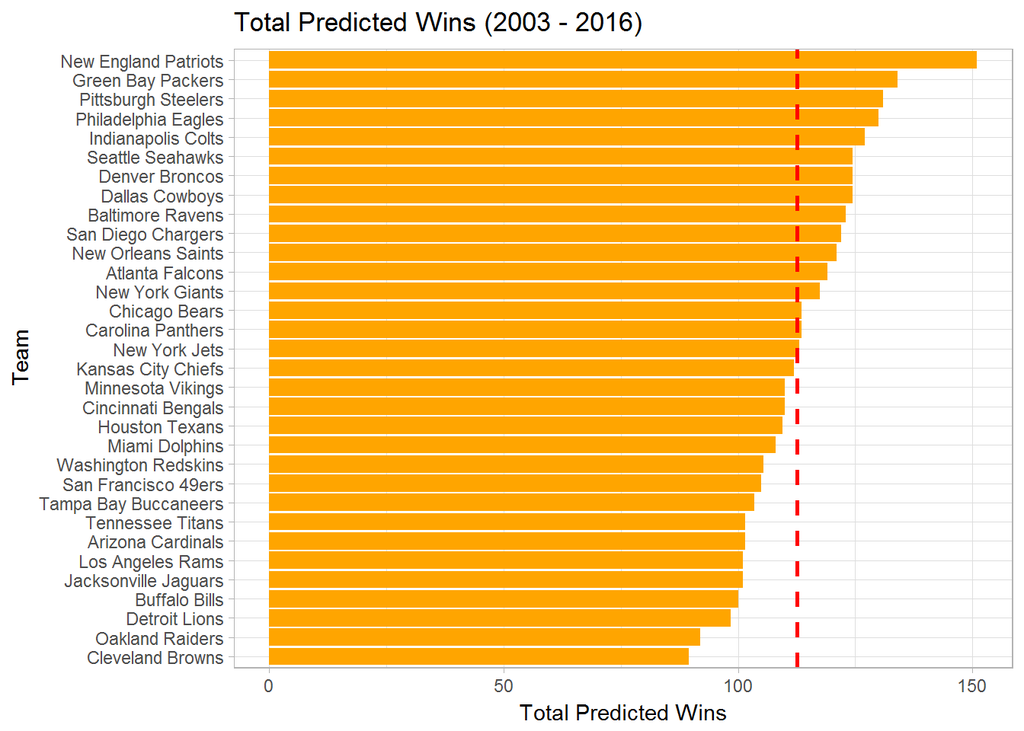

```r
by_team_sort_1 <- by_team %>%
  arrange(total_predicted_wins) %>%
  mutate(team_ordered = factor(team, levels = team))

by_team_sort_1 %>%
  ggplot(aes(team_ordered, total_predicted_wins)) +
  geom_bar(stat = "identity", fill = "orange") +
  geom_hline(aes(yintercept = median(total_predicted_wins)), color = "red", linetype=2, size = 1) +
  theme_light() +
  coord_flip() +
  labs(title="Total Predicted Wins (2003 - 2016)", x="Team", y="Total Predicted Wins")
```

```r
top_5_predicted_wins <- by_team %>%
  arrange(desc(total_predicted_wins)) %>%
  select(team) %>%
  rename(Top_5 = team)
top_5_predicted_wins %>% head(5)
```

```
# A tibble: 5 x 1
                 Top_5
                 <chr>
1 New England Patriots
2    Green Bay Packers
3  Pittsburgh Steelers
4  Philadelphia Eagles
5   Indianapolis Colts
```

```r
bottom_5_predicted_wins <- by_team %>%
  arrange(total_predicted_wins) %>%
  select(team) %>%
  rename(Bottom_5 = team)
bottom_5_predicted_wins %>% head(5)
```

```
# A tibble: 5 x 1
              Bottom_5
                 <chr>
1     Cleveland Browns
2      Oakland Raiders
3        Detroit Lions
4        Buffalo Bills
5 Jacksonville Jaguars
```

#### Total Actual Wins

##### As expected, this shows a similar pattern as the previous chart.

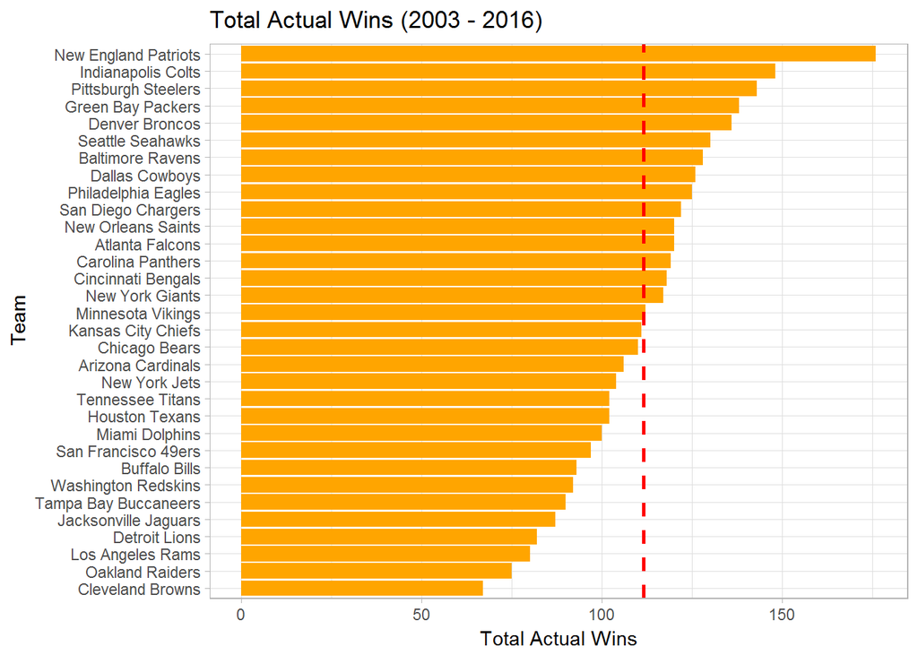

```r
by_team_sort_2 <- by_team %>%
  arrange(total_actual_wins) %>%
  mutate(team_ordered = factor(team, levels = team))

by_team_sort_2 %>%
  ggplot(aes(team_ordered, total_actual_wins)) +
  geom_bar(stat = "identity", fill = "orange") +
  geom_hline(aes(yintercept = median(total_actual_wins)), color = "red", linetype=2, size = 1) +
  theme_light() +
  coord_flip() +
  labs(title="Total Actual Wins (2003 - 2016)", x="Team", y="Total Actual Wins")
```

```r
top_5_actual_wins <- by_team %>%
  arrange(desc(total_actual_wins)) %>%
  select(team) %>%
  rename(Top_5 = team)
top_5_actual_wins %>% head(5)
```

```
# A tibble: 5 x 1
                 Top_5
                 <chr>
1 New England Patriots
2   Indianapolis Colts
3  Pittsburgh Steelers
4    Green Bay Packers
5       Denver Broncos
```

```r
bottom_5_actual_wins <- by_team %>%
  arrange(total_actual_wins) %>%
  select(team) %>%
  rename(Bottom_5 = team)
bottom_5_actual_wins %>% head(5)
```

```
# A tibble: 5 x 1
              Bottom_5
                 <chr>
1     Cleveland Browns
2      Oakland Raiders
3     Los Angeles Rams
4        Detroit Lions
5 Jacksonville Jaguars
```

#### Total Actual vs Predicted Wins

##### Because the numbers are slightly more negative, this again suggests that the Under would pay off more often.

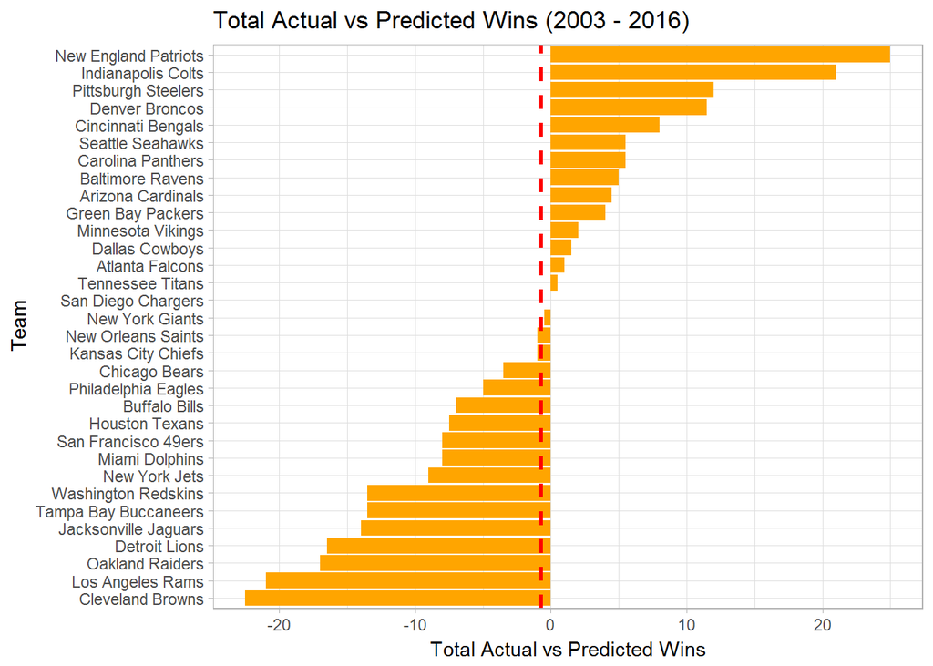

```r
by_team_sort_3 <- by_team %>%
  arrange(total_actual_vs_predicted) %>%
  mutate(team_ordered = factor(team, levels = team))

by_team_sort_3 %>%
  ggplot(aes(team_ordered, total_actual_vs_predicted)) +
  geom_bar(stat = "identity", fill = "orange") +
  geom_hline(aes(yintercept = median(total_actual_vs_predicted)), color = "red", linetype=2, size = 1) +
  theme_light() +
  coord_flip() +
  labs(title="Total Actual vs Predicted Wins (2003 - 2016)", x="Team", y="Total Actual vs Predicted Wins")
```

```r
top_5_actual_vs_predicted <- by_team %>%
  arrange(desc(total_actual_vs_predicted)) %>%
  select(team) %>%
  rename(Top_5 = team)
top_5_actual_vs_predicted %>% head(5)
```

```
# A tibble: 5 x 1
                 Top_5
                 <chr>
1 New England Patriots
2   Indianapolis Colts
3  Pittsburgh Steelers
4       Denver Broncos
5   Cincinnati Bengals
```

```r
bottom_5_actual_vs_predicted <- by_team %>%
  arrange(total_actual_vs_predicted) %>%
  select(team) %>%
  rename(Bottom_5 = team)
bottom_5_actual_vs_predicted %>% head(5)
```

```
# A tibble: 5 x 1
              Bottom_5
                 <chr>
1     Cleveland Browns
2     Los Angeles Rams
3      Oakland Raiders
4        Detroit Lions
5 Jacksonville Jaguars
```

#### Total Futures Win Miss

##### This shows the teams that have been more and less predictable. The Buffalo Bills really stand out as a team that the sportsbooks seems to predict very accurately.

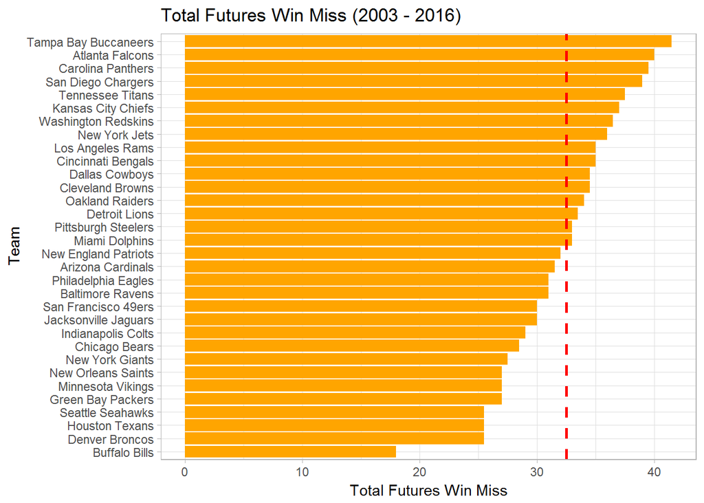

```r
by_team_sort_4 <- by_team %>%
  arrange(total_futures_win_miss) %>%
  mutate(team_ordered = factor(team, levels = team))

by_team_sort_4 %>%
  ggplot(aes(team_ordered, total_futures_win_miss)) +
  geom_bar(stat = "identity", fill = "orange") +
  geom_hline(aes(yintercept = median(total_futures_win_miss)), color = "red", linetype=2, size = 1) +
  theme_light() +
  coord_flip() +
  labs(title="Total Futures Win Miss (2003 - 2016)", x="Team", y="Total Futures Win Miss")
```

```r
top_5_futures_win_miss <- by_team %>%
  arrange(desc(total_futures_win_miss)) %>%
  select(team) %>%
  rename(Top_5 = team)
top_5_futures_win_miss %>% head(5)
```

```
# A tibble: 5 x 1
                 Top_5
                 <chr>
1 Tampa Bay Buccaneers
2      Atlanta Falcons
3    Carolina Panthers
4   San Diego Chargers
5     Tennessee Titans
```

```r
bottom_5_futures_win_miss <- by_team %>%
  arrange(total_futures_win_miss) %>%
  select(team) %>%
  rename(Bottom_5 = team)
bottom_5_futures_win_miss %>% head(5)
```

```
# A tibble: 5 x 1
           Bottom_5
              <chr>
1     Buffalo Bills
2    Denver Broncos
3    Houston Texans
4  Seattle Seahawks
5 Green Bay Packers
```

#### Total Point Differential

##### This chart shows, by point differential, how dominant the New England Patriots have been.

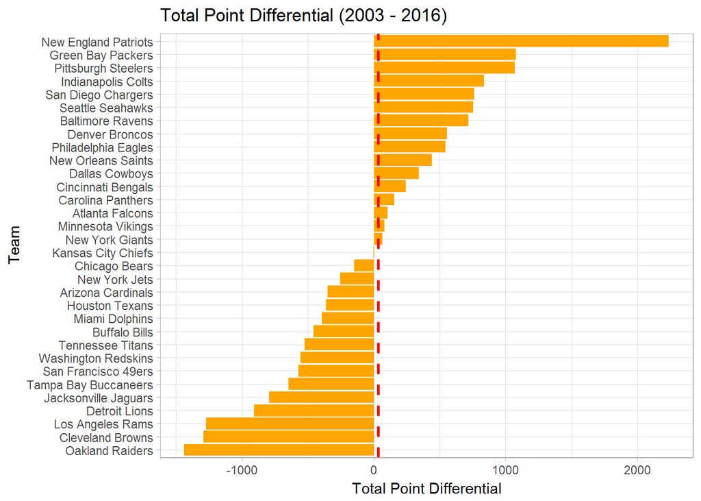

```r
by_team_sort_5 <- by_team %>%
  arrange(total_point_differential) %>%
  mutate(team_ordered = factor(team, levels = team))

by_team_sort_5 %>%
  ggplot(aes(team_ordered, total_point_differential)) +
  geom_bar(stat = "identity", fill = "orange") +
  geom_hline(aes(yintercept = median(total_point_differential)), color = "red", linetype=2, size = 1) +
  theme_light() +
  coord_flip() +
  labs(title="Total Point Differential (2003 - 2016)", x="Team", y="Total Point Differential")
```

```r
top_5_point_differential <- by_team %>%
  arrange(desc(total_point_differential)) %>%
  select(team) %>%
  rename(Top_5 = team)
top_5_point_differential %>% head(5)
```

```
# A tibble: 5 x 1
                 Top_5
                 <chr>
1 New England Patriots
2    Green Bay Packers
3  Pittsburgh Steelers
4   Indianapolis Colts
5   San Diego Chargers
```

```r
bottom_5_point_differential <- by_team %>%
  arrange(total_point_differential) %>%
  select(team) %>%
  rename(Bottom_5 = team)
bottom_5_point_differential %>% head(5)
```

```
# A tibble: 5 x 1
              Bottom_5
                 <chr>
1      Oakland Raiders
2     Cleveland Browns
3     Los Angeles Rams
4        Detroit Lions
5 Jacksonville Jaguars
```

## Part 3 - Post Interactive Statistics on Shiny App

#### https://ski2488.shinyapps.io/Final_Project/

```r
shinyUI(fluidPage(
  titlePanel("Historical NFL Football Statistics"),
  sidebarLayout(sidebarPanel(
    sliderInput(
      "theNumberSlider",
      h3(strong("Year Range: "), style = "color:darkblue"),
      min = 2003,
      max = 2016,
      value = c(2003,2016)
    ),
    selectInput("teamSelector",
                h3(strong("Select Team:"), style = "color:darkblue"),
                choice = c("Arizona Cardinals", "Atlanta Falcons", "Baltimore Ravens", "Buffalo Bills", "Carolina Panthers", "Chicago Bears",
                           "Cincinnati Bengals", "Cleveland Browns", "Dallas Cowboys", "Denver Broncos", "Detroit Lions", "Green Bay Packers",
                           "Houston Texans", "Indianapolis Colts", "Jacksonville Jaguars", "Kansas City Chiefs", "Los Angeles Rams",
                           "Miami Dolphins", "Minnesota Vikings", "New England Patriots", "New Orleans Saints", "New York Giants",
                           "New York Jets", "Oakland Raiders", "Philadelphia Eagles", "Pittsburgh Steelers", "San Diego Chargers",
                           "San Francisco 49ers", "Seattle Seahawks", "Tampa Bay Buccaneers", "Tennessee Titans", "Washington Redskins"
                ),
                selected = "Arizona Cardinals"),
    actionButton(inputId = "click",
                 label = em(strong("Run Update")), style = "color:red"),
    fluidRow(
      h3(strong("Key Statisitics:"), style = "color:darkblue")),
    fluidRow(
      h4("Total Predicted Wins"),
      textOutput("showFutures")),
    fluidRow(
      h4("Total Actual Wins"),
      textOutput("ShowWins")),
    fluidRow(
      h4("Actual Wins vs Predicted Wins"),
      textOutput("showActualvsPred")),
    fluidRow(
      h4("Absolute Actual Wins vs Predicted Wins"),
      textOutput("showAbsActualvsPred")),
    fluidRow(
      h4("Total Point Differential"),
      textOutput("showPointDiff")),
    fluidRow(
      h4("Percentage Over"),
      textOutput("showOver")),
    fluidRow(
      h4("Percentage Under"),
      textOutput("showUnder")),
    fluidRow(
      h4("Percentage Push"),
      textOutput("showPush"))
    ),
  mainPanel(
    column(3,plotOutput("showPlot")),
    column(3,plotOutput("showPlot2")),
    column(3,plotOutput("showPlot3")),
    column(3,plotOutput("showPlot4")),
    column(3,plotOutput("showPlot5")),
    column(3,plotOutput("showPlot6")),
    column(3,plotOutput("showPlot7")),
    column(3,plotOutput("showPlot8")),
    tableOutput("showTheTable")
  ))
))

shinyServer(function(input, output) {
  team_filter <- eventReactive (input$click, {
    joined_data %>%
      filter(year >= input$theNumberSlider[1] & year <= input$theNumberSlider[2] & team == input$teamSelector) %>%
      select(-team, -odds_over, -odds_under, -last_year_wins_f:-points_against, -last_year_wins_s:-last_year_point_differential)
  })
  all_filter_1 <- eventReactive (input$click, {
    joined_data %>%
      filter(year >= input$theNumberSlider[1] & year <= input$theNumberSlider[2]) %>%
      group_by(team) %>%
      summarise(stat = sum(predicted_wins, na.rm = TRUE)) %>%
      arrange(stat) %>%
      mutate(team_ordered = factor(team, levels = team))
  })
  all_filter_2 <- eventReactive (input$click, {
    joined_data %>%
      filter(year >= input$theNumberSlider[1] & year <= input$theNumberSlider[2]) %>%
      group_by(team) %>%
      summarise(stat = sum(actual_wins, na.rm = TRUE)) %>%
      arrange(stat) %>%
      mutate(team_ordered = factor(team, levels = team))
  })
  all_filter_3 <- eventReactive (input$click, {
    joined_data %>%
      filter(year >= input$theNumberSlider[1] & year <= input$theNumberSlider[2]) %>%
      group_by(team) %>%
      summarise(stat = sum(actual_vs_predicted, na.rm = TRUE)) %>%
      arrange(stat) %>%
      mutate(team_ordered = factor(team, levels = team))
  })
  all_filter_4 <- eventReactive (input$click, {
    joined_data %>%
      filter(year >= input$theNumberSlider[1] & year <= input$theNumberSlider[2]) %>%
      group_by(team) %>%
      summarise(stat = sum(absolute_actual_vs_predicted, na.rm = TRUE)) %>%
      arrange(stat) %>%
      mutate(team_ordered = factor(team, levels = team))
  })
  total_futures <- eventReactive (input$click, {
    joined_data %>%
      group_by(team) %>%
      filter(year >= input$theNumberSlider[1] & year <= input$theNumberSlider[2] & team == input$teamSelector) %>%
      summarise(total = sum(predicted_wins)) %>%
      select(total)
  })
  team_change <- eventReactive (input$click, {
    input$teamSelector
  })
  total_wins <- eventReactive (input$click, {
    joined_data %>%
      group_by(team) %>%
      filter(year >= input$theNumberSlider[1] & year <= input$theNumberSlider[2] & team == input$teamSelector) %>%
      summarise(total = sum(actual_wins)) %>%
      select(total)
  })
  total_actual_vs_pred <- eventReactive (input$click, {
    joined_data %>%
      group_by(team) %>%
      filter(year >= input$theNumberSlider[1] & year <= input$theNumberSlider[2] & team == input$teamSelector) %>%
      summarise(total = sum(actual_vs_predicted)) %>%
      select(total)
  })
  total_abs_actual_vs_pred <- eventReactive (input$click, {
    joined_data %>%
      group_by(team) %>%
      filter(year >= input$theNumberSlider[1] & year <= input$theNumberSlider[2] & team == input$teamSelector) %>%
      summarise(total = sum(absolute_actual_vs_predicted)) %>%
      select(total)
  })
  total_point_diff <- eventReactive (input$click, {
    joined_data %>%
      group_by(team) %>%
      filter(year >= input$theNumberSlider[1] & year <= input$theNumberSlider[2] & team == input$teamSelector) %>%
      summarise(total = sum(point_differential)) %>%
      select(total)
  })
  total_perc_over <- eventReactive (input$click, {
    joined_data %>%
      group_by(team) %>%
      filter(year >= input$theNumberSlider[1] & year <= input$theNumberSlider[2] & team == input$teamSelector) %>%
      summarise(total = sum(result == "Over", na.rm = TRUE) / (sum(result == "Over", na.rm = TRUE) + sum(result == "Under", na.rm = TRUE) + sum(result == "Push", na.rm = TRUE))) %>%
      select(total)
  })
  total_perc_under <- eventReactive (input$click, {
    joined_data %>%
      group_by(team) %>%
      filter(year >= input$theNumberSlider[1] & year <= input$theNumberSlider[2] & team == input$teamSelector) %>%
      summarise(total = sum(result == "Under", na.rm = TRUE) / (sum(result == "Over", na.rm = TRUE) + sum(result == "Under", na.rm = TRUE) + sum(result == "Push", na.rm = TRUE))) %>%
      select(total)
  })
  total_perc_push <- eventReactive (input$click, {
    joined_data %>%
      group_by(team) %>%
      filter(year >= input$theNumberSlider[1] & year <= input$theNumberSlider[2] & team == input$teamSelector) %>%
      summarise(total = sum(result == "Push", na.rm = TRUE) / (sum(result == "Over", na.rm = TRUE) + sum(result == "Under", na.rm = TRUE) + sum(result == "Push", na.rm = TRUE))) %>%
      select(total)
  })

  observeEvent(input$click, {
    output$showTeam <- renderText({team_change()
    })
    output$showFutures <- renderText({sum(total_futures())
    })
    output$ShowWins <- renderText({sum(total_wins())
    })
    output$showActualvsPred <- renderText({sum(total_actual_vs_pred())
    })
    output$showAbsActualvsPred <- renderText({sum(total_abs_actual_vs_pred())
    })
    output$showPointDiff <- renderText({sum(total_point_diff())
    })
    output$showOver <- renderText({sum(total_perc_over())
    })
    output$showUnder <- renderText({sum(total_perc_under())
    })
    output$showPush <- renderText({sum(total_perc_push())
    })
    output$showTheTable <- renderTable({team_filter()
    })
    output$showPlot <- renderPlot({team_filter() %>%
        ggplot() +
        geom_histogram(aes(predicted_wins), fill = "orange", color = "black", binwidth = .5, show.legend = FALSE) +
        scale_x_continuous(breaks = seq(0,16,.5)) +
        theme_light() +
        labs(title="Predicted Wins", x="", y="Total Count")
    })
    output$showPlot2 <- renderPlot({team_filter() %>%
        ggplot() +
        geom_histogram(aes(actual_wins), fill = "blue", color = "black", binwidth = 1, show.legend = FALSE) +
        scale_x_continuous(breaks = seq(0,16,1)) +
        theme_light() +
        labs(title="Actual Wins", x="", y="")
    })
    output$showPlot3 <- renderPlot({team_filter() %>%
        ggplot() +
        geom_histogram(aes(actual_vs_predicted), fill = "green", color = "black", binwidth = .5, show.legend = FALSE) +
        scale_x_continuous(breaks = seq(-10,10)) +
        theme_light() +
        labs(title="Actual vs Predicted", x="", y="")
    })
    output$showPlot4 <- renderPlot({team_filter() %>%
        ggplot() +
        geom_histogram(aes(absolute_actual_vs_predicted), fill = "gray", color = "black", binwidth = .5, show.legend = FALSE) +
        scale_x_continuous(breaks = seq(0,16,.5)) +
        theme_light() +
        labs(title="Absolute Actual vs Predicted", x="", y="")
    })
    output$showPlot5 <- renderPlot({all_filter_1() %>%
        ggplot(aes(team_ordered, stat)) +
        geom_bar(stat = "identity", fill = "orange") +
        geom_hline(aes(yintercept = median(stat)), color = "red", linetype=2, size = 1) +
        theme_light() +
        coord_flip() +
        labs(title="", x="Team", y="Predicted Wins")
    })
    output$showPlot6 <- renderPlot({all_filter_2() %>%
        ggplot(aes(team_ordered, stat)) +
        geom_bar(stat = "identity", fill = "blue") +
        geom_hline(aes(yintercept = median(stat)), color = "red", linetype=2, size = 1) +
        theme_light() +
        coord_flip() +
        labs(title="", x="", y="Actual Wins")
    })
    output$showPlot7 <- renderPlot({all_filter_3() %>%
        ggplot(aes(team_ordered, stat)) +
        geom_bar(stat = "identity", fill = "green") +
        geom_hline(aes(yintercept = median(stat)), color = "red", linetype=2, size = 1) +
        theme_light() +
        coord_flip() +
        labs(title="", x="", y="Actual vs Predicted")
    })
    output$showPlot8 <- renderPlot({all_filter_4() %>%
        ggplot(aes(team_ordered, stat)) +
        geom_bar(stat = "identity", fill = "gray") +
        geom_hline(aes(yintercept = median(stat)), color = "red", linetype=2, size = 1) +
        theme_light() +
        coord_flip() +
        labs(title="", x="", y="Absolute Actual vs Predicted")
    })
})
})
```